# Leave-one-out cross validation model checking and comparison: Roaches

Author

Aki Vehtari

Published

2017-01-10

Modified

2026-08-26

This notebook includes the code for the Bayesian Workflow book Chapter 24 *Leave-one-out cross validation model checking and comparison: Roaches*.

# 1 Introduction

This case study demonstrates cross-validation model comparison, and posterior and cross-validation predictive checking of models. Furthermore the notebook demonstrates how to use integrated PSIS-LOO with varying intercept (“random effect”) models.

**Load packages**

````r
library(rprojroot)
root <- has_file(".Bayesian-Workflow-root")$make_fix_file()
library(loo)
library(rstantools)
library(brms)
library(cmdstanr)
# CmdStanR output directory makes Quarto cache to work
dir.create(root("roaches", "stan_output"), showWarnings = FALSE)
options(cmdstanr_output_dir = root("roaches", "stan_output"))
options(mc.cores = 4)
library(ggplot2)
library(khroma)
library(ggdist)
library(bayesplot)
theme_set(bayesplot::theme_default(base_family = "sans", base_size = 16))
library(posterior)
options(posterior.num_args = list(digits = 2))
library(priorsense)
library(dplyr)
library(tibble)
library(reliabilitydiag)
set.seed(298465)

print_stan_file <- function(file) {
  code <- readLines(file)
  if (isTRUE(getOption("knitr.in.progress")) &
        identical(knitr::opts_current$get("results"), "asis")) {
    # In render: emit as-is so Pandoc/Quarto does syntax highlighting
    block <- paste0("```stan", "\n", paste(code, collapse = "\n"), "\n", "```")
    knitr::asis_output(block)
  } else {
    writeLines(code)
  }
}
````

# 2 Data

The roaches data example comes from Chapter 8.3 of Gelman and Hill (2007).

> the treatment and control were applied to 160 and 104 apartments, respectively, and the outcome measurement $y_i$ in each apartment $i$ was the number of roaches caught in a set of traps. Different apartments had traps for different numbers of days

In addition to an intercept, the regression predictors for the model are the pre-treatment number of roaches `roach1`, the treatment indicator `treatment`, and a variable indicating whether the apartment is in a building restricted to elderly residents `senior`. The distribution of `roach1` is very skewed and we take a square root of it. Because the number of days for which the roach traps were used is not the same for all apartments in the sample, we include it as an `exposure2` by adding $\ln(u_i)$) to the linear predictor $\eta_i$ and it can be specified using the `offset` argument in `brms`.

Load data

```r
data(roaches, package = "rstanarm")
roaches$sqrt_roach1 <- sqrt(roaches$roach1)
head(roaches) |> print(digits = 2)
```

```
    y roach1 treatment senior exposure2 sqrt_roach1
1 153  308.0         1      0       0.8        17.5
2 127  331.2         1      0       0.6        18.2
3   7    1.7         1      0       1.0         1.3
4   7    3.0         1      0       1.0         1.7
5   0    2.0         1      0       1.1         1.4
6   0    0.0         1      0       1.0         0.0
```

# 3 Poisson model

Fit a Poisson regression model with `brms`

```r
fit_p <- brm(y ~ sqrt_roach1 + treatment + senior + offset(log(exposure2)),
             data = roaches,
             family = poisson,
             prior = prior(normal(0, 1), class = b),
             refresh = 0)
```

Plot posterior

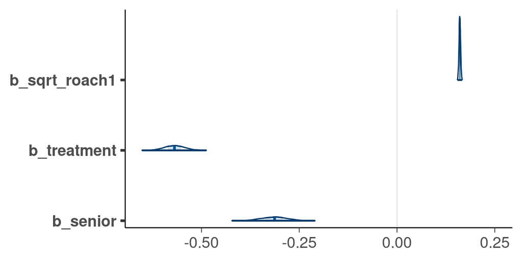

Figure 1

```r
mcmc_areas(fit_p, regex_pars = c("sqrt_roach1", "treatment", "senior"),
           prob_outer = 0.999) +
  coord_cartesian(xlim = c(-0.65, 0.25))
```

All marginal posteriors are clearly away from zero. We need to do some model checking before trusting these.

## 3.1 Posterior predictive checking

Posterior predictive checking can often detect problems and also provide more information about the reason. As the range of counts is large, we can use kernel density estimate plot (Säilynoja et al. 2025).

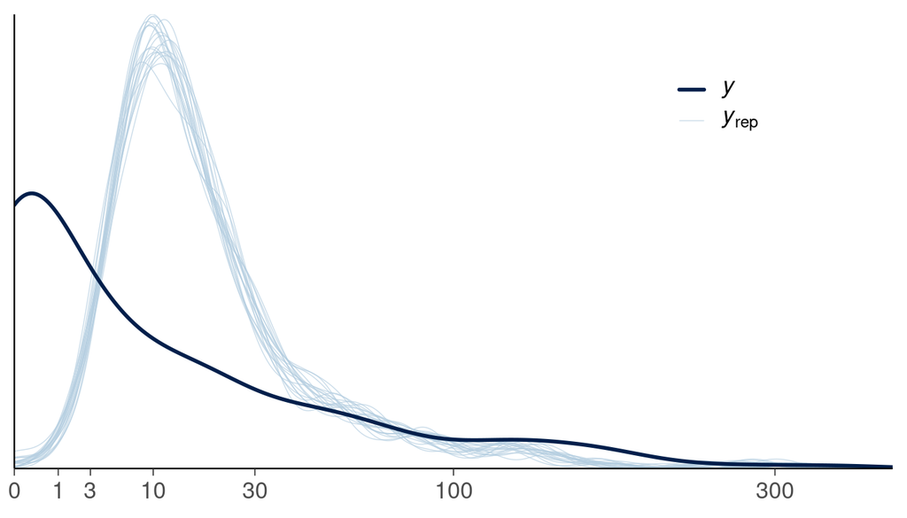

Figure 2

```r
pp_check(fit_p, type = "dens_overlay", ndraws = 20) +
  scale_x_sqrt(breaks = c(0, 1, 3, 10, 30, 100, 300),
               lim = c(0, 400)) +
  theme(legend.position = "inside",
        legend.position.inside = c(0.8, 0.8))
```

We see that the marginal distribution of model replicated data is clearly different from the observed data which are more dispersed. Posterior predictive checking can sometimes have significant bias due to double use of the data, but in this case the discrepancy is so big that further checks are not needed.

Although in this case the model misspecification is obvious with kernel density plot, too, for count the often a better choice is a rootogram variant proposed by Säilynoja et al. (2025).

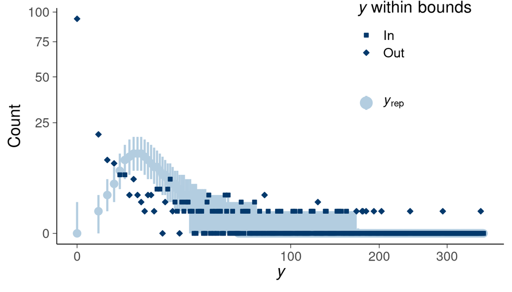

Figure 3

```r
pp_check(fit_p, type = "rootogram", style = "discrete") +
  scale_x_sqrt() +
  theme(legend.position = "inside",
        legend.position.inside = c(0.8, 0.8))
```

## 3.2 Cross-validation model comparison

For demonstration, we show what would happen in cross validation based model comparison if we would ignore posterior predictive checking result.

We use Pareto-smoothed importance sampling leave-one-out (PSIS-LOO) cross-validation (Vehtari, Gelman, and Gabry 2017) as it is very fast to compute.

```r
fit_p <- add_criterion(fit_p, criterion = "loo")
# store the result for later use
loo_p1 <- loo(fit_p)
```

We get warning about high Pareto-$\hat{k}$’s in PSIS-LOO computation and recompute using moment matching (Paananen et al. 2021) which translates and scales the posterior draws to better match the moments of the leave-one-out posteriors (done only for the folds with high Pareto-$\hat{k}$)

```r
fit_p <- add_criterion(
  fit_p,
  criterion = "loo",
  moment_match = TRUE,
  overwrite = TRUE
)
```

Now all Pareto-$\hat{k}$’s are ok, and we examine LOO results.

```r
loo(fit_p)
```

```
Computed from 4000 by 262 log-likelihood matrix.

         Estimate     SE
elpd_loo  -5479.3  700.1
p_loo       275.3   61.9
looic     10958.5 1400.3
------
MCSE of elpd_loo is NA.
MCSE and ESS estimates assume independent draws (r_eff=1).

All Pareto k estimates are good (k < 0.7).
See help('pareto-k-diagnostic') for details.
```

For demonstration, we show what would happen if we would try to use cross validation based model comparison to assess predictive relevance of the covariates. We later compare these to results when using better models.

We form 3 models by dropping each of the covariates out at a time.

```r
fit_p_m1 <- update(fit_p, formula = y ~ treatment + senior) |>
  add_criterion(criterion = "loo", moment_match = TRUE)
fit_p_m2 <- update(fit_p, formula = y ~ sqrt_roach1 + senior)  |>
  add_criterion(criterion = "loo", moment_match = TRUE)
fit_p_m3 <- update(fit_p, formula = y ~ sqrt_roach1 + treatment) |>
  add_criterion(criterion = "loo", moment_match = TRUE)
```

Moment matching is able to assist PSIS-LOO computation and all Pareto $\hat{k}$ values are good.

```r
loo_compare(fit_p, fit_p_m1, fit_p_m2, fit_p_m3,
            model_names = c("Poisson full model",
                            "Poisson w/o sqrt(roach1)",
                            "Poisson w/o treatment",
                            "Poisson w/o senior"))
```

```
                    model elpd_diff se_diff p_worse diag_diff diag_elpd
       Poisson w/o senior       0.0     0.0      NA
       Poisson full model     -13.0   180.6    0.53
    Poisson w/o treatment    -216.7   228.2    0.83
 Poisson w/o sqrt(roach1)   -2750.4   638.1    1.00
```

Based on `elpd_diff` and `se_diff` the roaches covariate would be relevant, but although dropping treatment or senior covariate will make a large change to elpd, the uncertainty is also very large and cross-validation indicates that these covariates are not necessarily relevant. The posterior marginals are conditional on the model, but cross-validation is more cautious by not using any model for the future data distribution. The column `p_worse` provides a normal approximation base probability that the model is worse than the model with the best performance. The column `diag_diff` indicates that the distributions of the pointwise performance differences are likely to have so thick tails that the normal approximation based on `elpd_diff` and `diff_se` is not well calibrated, and we can’t trust the `p_worse` values. In this case, the thick tails in the pointwise performance differences are likely due to Poisson model being underdispersed compared to the data.

# 4 Negative binomial model

We change the Poisson model to a more robust negative binomial model. Often it would be sensible to start with negative binomial model for counts and skip the Poisson model. The negative-binomial shape parameter has the `brms` default prior, which is inverse-gamma$(.4, .3)$ (Vehtari 2024).

```r
fit_nb <- update(fit_p, family = negbinomial)
```

Plot posterior

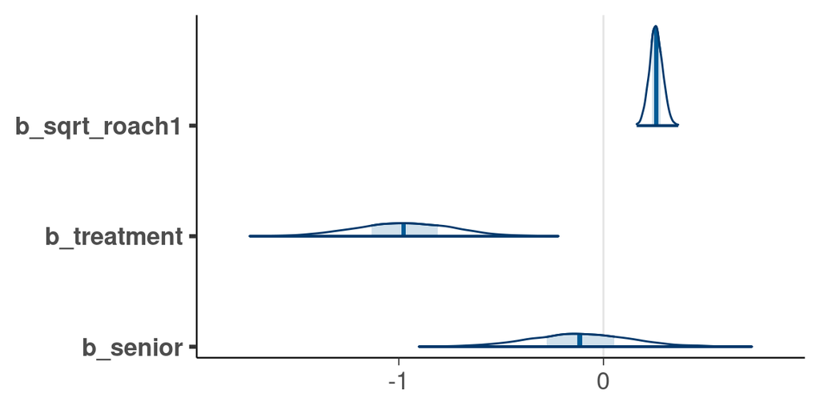

Figure 4

```r
mcmc_areas(fit_nb, regex_pars = c("sqrt_roach1", "treatment", "senior"),
           prob_outer = 0.999)
```

## 4.1 Posterior and LOO predictive checking

We use posterior predictive checking to compare marginal data and predictive distributions.

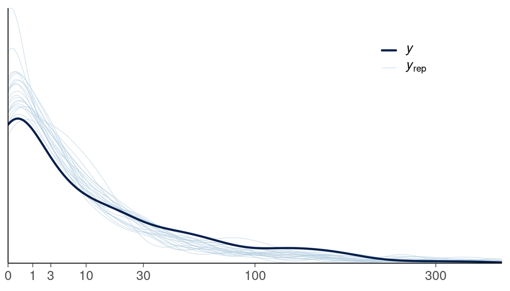

Figure 5

```r
pp_check(fit_nb, type = "dens_overlay", ndraws = 20) +
  scale_x_sqrt(breaks = c(0, 1, 3, 10, 30, 100, 300),
               lim = c(0, 400)) +
  theme(legend.position = "inside",
        legend.position.inside = c(0.8, 0.8))
```

We see that the negative-binomial model is much better although it seems that the model predictive distribution has more mass for small counts than the real data. This discrepancy can also be an artifact from the kernel density estimate, and it is better to examine discrete rootogram

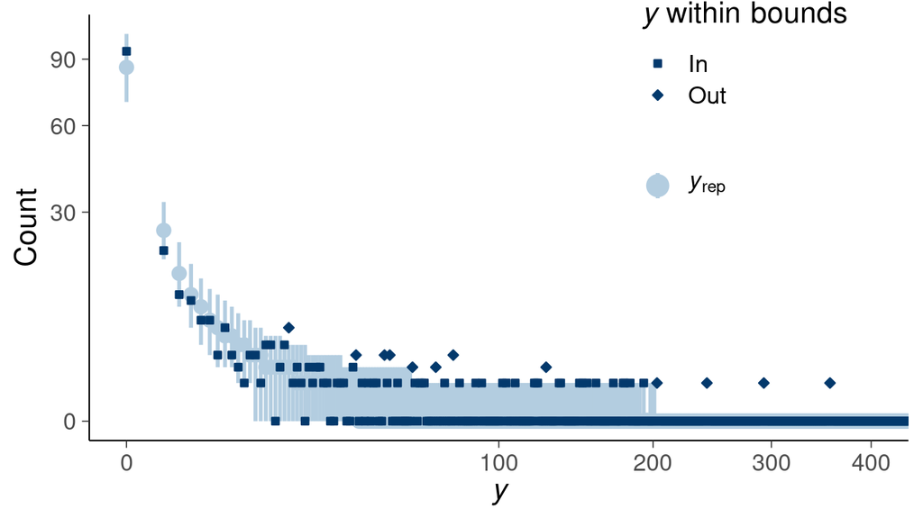

Figure 6

```r
pp_check(fit_nb, type = "rootogram", style = "discrete") +
  scale_x_sqrt() +
  coord_cartesian(xlim = c(0, 400)) +
  theme(legend.position = "inside",
        legend.position.inside = c(0.8, 0.8))
```

We see that the negative-binomial model is quite good, and there is no clear discrepancy based on the predictive intervals and data.

Instead of looking at the marginal distribution, we can look at the pointwise predictive distribution and corresponding observations.

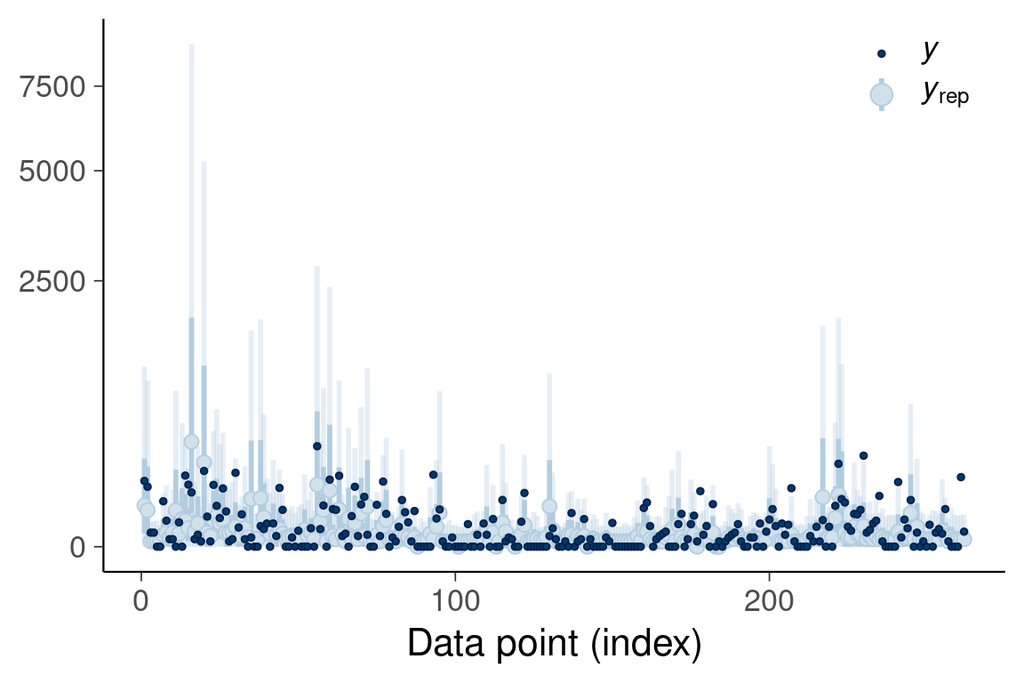

Figure 7

```r
pp_check(fit_nb, "intervals") +
  scale_y_sqrt() +
  theme(legend.position = "inside",
        legend.position.inside = c(0.9, 0.9))
```

If the model predictive distributions are well calibrated, then the observations should look like randomly drawn from the predictive distributions. We can use a `pit_ecdf` to make probability integral transformation (PIT) plot to make the comparison of pointwise posterior predictive distributions and data. One PIT value is the cumulative density of one observation given the corresponding conditional predictive distribution. If the pointwise predictive distributions are well calibrated, PIT values are (almost) uniformly distributed. PIT-ECDF plot compares observed PIT values to uniform distribution.

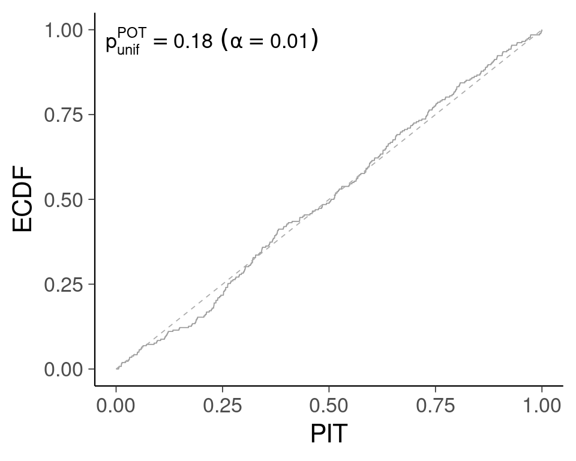

Figure 8

```r
pp_check(fit_nb, type = "pit_ecdf", method = "correlated")
```

Now that posterior predictive check looks quite good, it is useful to be more careful and use LOO predictive checking, too. We first run PSIS-LOO computation to check it works.

```r
fit_nb <- add_criterion(fit_nb, criterion = "loo")
# store the result for later use
loo_nb1 <- loo(fit_nb)
```

We get warning about high Pareto-$\hat{k}$ and to improve computation accuracy, we re-run with moment matching. We later need some Pareto smoothed importance sampling intermediate computation results and save them, too.

```r
fit_nb <- add_criterion(
  fit_nb,
  criterion = "loo",
  moment_match = TRUE,
  save_psis = TRUE,
  overwrite = TRUE
)
```

Let’s look at the LOO results.

```r
(loo_nb <- loo(fit_nb))
```

```
Computed from 4000 by 262 log-likelihood matrix.

         Estimate   SE
elpd_loo   -881.9 38.3
p_loo         8.5  3.8
looic      1763.9 76.6
------
MCSE of elpd_loo is 0.1.
MCSE and ESS estimates assume MCMC draws (r_eff in [0.7, 1.4]).

All Pareto k estimates are good (k < 0.7).
See help('pareto-k-diagnostic') for details.
```

All Pareto-$\hat{k}$ are good indicating PSIS-LOO computation with moment matching works well. `p_loo` is closer to the actual number of parameters, but still slightly larger than the total number of parameters 5 which is slightly suspicious. `p_loo` is small compared to the number of observations and we may expect pointwise LOO predictive intervals to be similar to pointwise posterior predictive intervals, and LOO-PIT-ECDF to look similar to posterior PIT-ECDF. Although we had used moment matching above, some intermediate results are not stored as they may take a lot of memory, and we use moment matching argument again when computing LOO intervals and LOO-PIT’s.

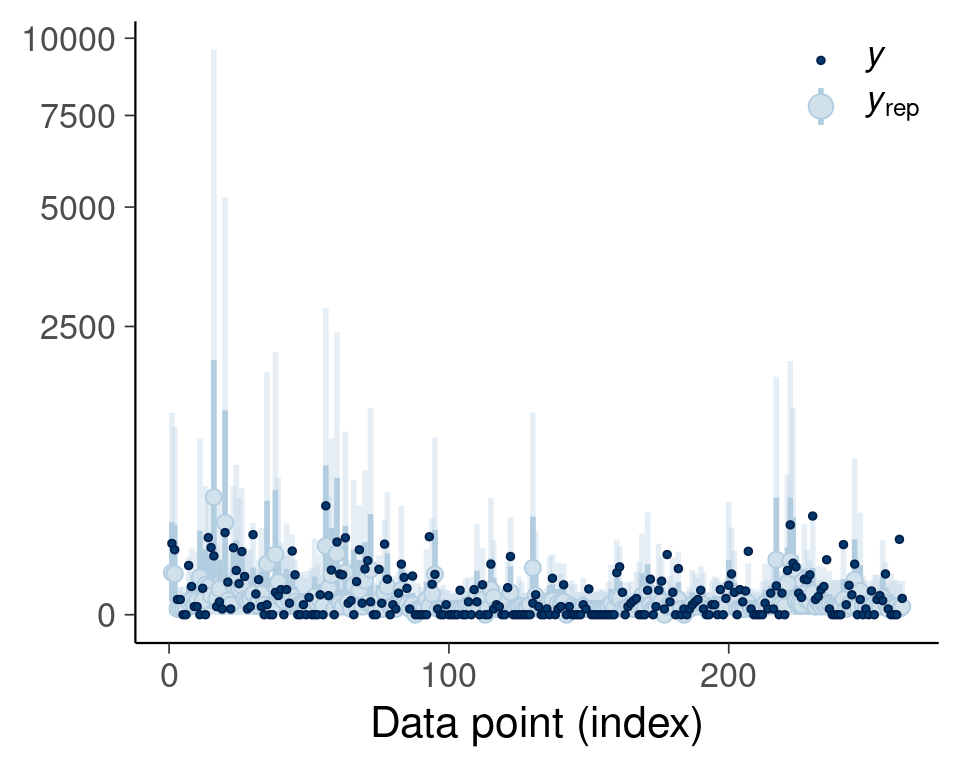

Figure 9

```r
pp_check(fit_nb, "loo_intervals", moment_match = TRUE) +
  scale_y_sqrt() +
  theme(legend.position = "inside",
        legend.position.inside = c(0.9, 0.9))
```

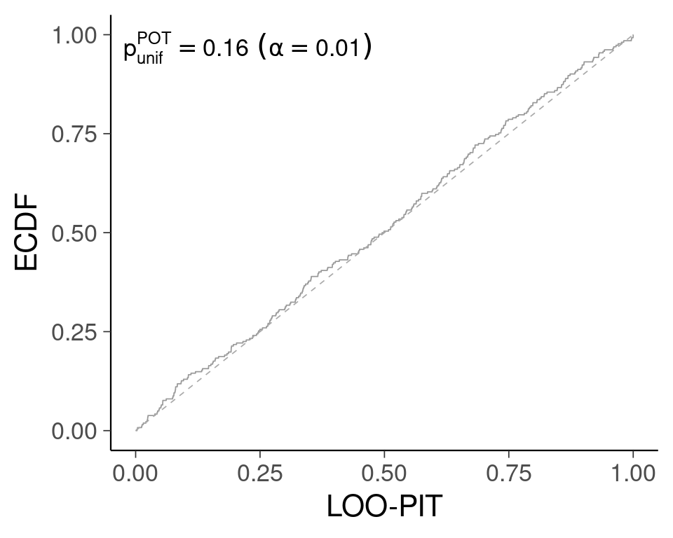

Figure 10

```r
pp_check(fit_nb, type = "loo_pit_ecdf", moment_match = TRUE,
         method = "correlated")
```

As we guessed, there is not much difference between LOO and posterior intervals, and LOO-PIT-ECDF and PIT-ECDF.

```r
loo_compare(fit_p, fit_nb, model_names = c("Poisson", "Neg-bin"))
```

```
   model elpd_diff se_diff p_worse diag_diff diag_elpd
 Neg-bin       0.0     0.0      NA
 Poisson   -4597.3   680.1    1.00
```

In LOO model comparison the negative binomial model is much better than the Poisson model. The diagnostic `diag_diff` indicates the pointwise performance differences are likely to have thick tails, which is again likely due to the Poisson model being underdispersed. As we have made the model checking, we know that the Poisson model is misspecified and could be dropped just based on that fact. As the difference is very big and many times bigger than `diff_se`, we can also be certain that negative binomials model has better predictive performance.

The next comparison shows the result without moment matching improved computation.

```r
loo_compare(list(`Poisson` = loo_p1, `Neg-bin` = loo_nb1))
```

```
   model elpd_diff se_diff p_worse diag_diff       diag_elpd
 Neg-bin       0.0     0.0      NA            1 k_psis > 0.7
 Poisson   -4579.0   674.3    1.00           19 k_psis > 0.7
```

The difference is now a bit smaller, but still the difference is huge. The column `diag_elpd` is reminding us that there were high Pareto k values in PSIS-LOO computation. This illustrates that we don’t always need to improve PSIS-LOO computation to get rid of all high Pareto-$\hat{k}$’s, if the difference between the models is clearly bigger than possible bias.

As Poisson is a special case of negative-Binomial, instead of using cross validation model comparison, we could have also seen that Poisson is not a good model by looking at the posterior of the over-dispersion parameter (which gets very small values), and there would not have been a need to fit the Poisson model at all.

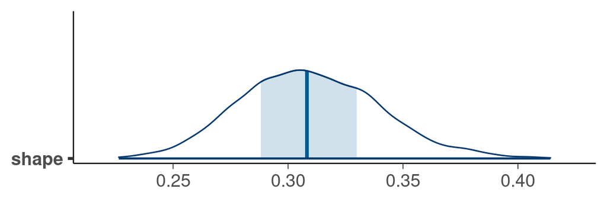

Figure 11

```r
mcmc_areas(fit_nb, pars = "shape", prob_outer = 0.999)
```

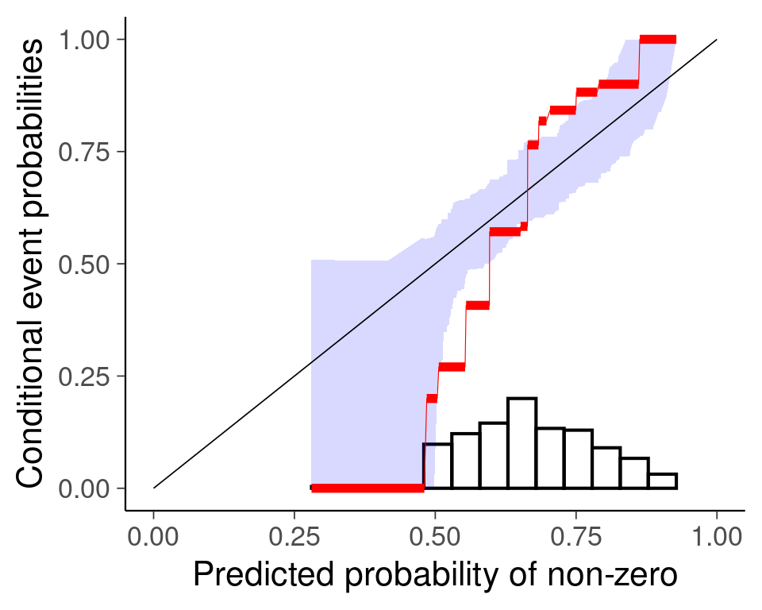

Figure 12

```r
rd <- reliabilitydiag(
  EMOS = E_loo((posterior_predict(fit_nb) > 0) + 0, loo_nb$psis_object)$value,
  y = as.numeric(roaches$y > 0)
)
autoplot(rd) +
  labs(x = "Predicted probability of non-zero",
       y = "Conditional event probabilities") +
  bayesplot::theme_default(base_family = "sans", base_size = 16)
```

There is a slight miscalibration indicated by red curve being quite much outside of the blue envelope. We later build a zero-inflated model to test whether that would improve calibration and predictive performance.

# 5 Poisson model with varying intercepts

Sometimes overdispersion is modelled by adding varying intercepts (“random effects”) for each individual. Negative-binomial model can be considered as mixture of Poissons with mixing distribution being a gamma distribution. It is common to use normal prior for varying intercepts in log intensity scale. This kind of varying intercept model may fit the data better than negative binomial model for two reasons. First, it is possible that the normal variation in log intensity scale is closer to actual variation. Second, explicitly presenting the latent values and using a prior makes the model slightly more flexible as the posterior of the varying intercepts can be different from the prior. However, in this case with just one observation per varying intercept, it is likely that the posterior is close to normal as likelihood contribution from one observation for each varying intercept is weak. The following example demonstrates computational challenges with varying intercept approach.

We add varying intercept for each observation with normal prior using the formula term `(1 | id)`. We use run the sampling four times longer to get high enough effective sample sizes.

```r
roaches$id <- 1:dim(roaches)[1]
fit_pvi <- brm(y ~ sqrt_roach1 + treatment + senior + (1 | id) + offset(log(exposure2)),
                  data = roaches, family = poisson,
                  prior = prior(normal(0, 1), class = b),
                  warmup = 1000, iter = 5000, thin = 4,
                  refresh = 0)
```

## 5.1 Analyse posterior

Plot posterior

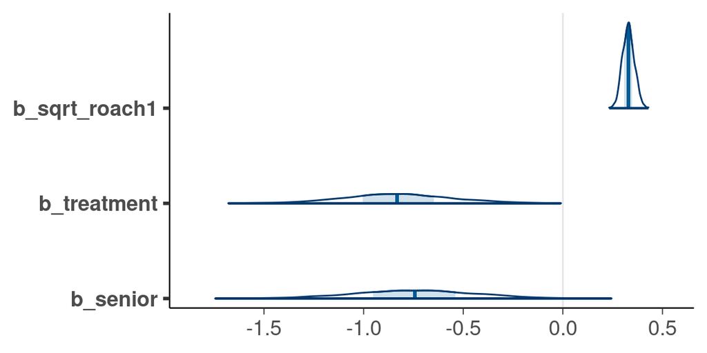

Figure 13

```r
mcmc_areas(fit_pvi, regex_pars = c("sqrt_roach1", "treatment", "senior"),
           prob_outer = .999)
```

## 5.2 Cross-validation checking

Compute LOO using PSIS-LOO.

```r
fit_pvi <- add_criterion(fit_pvi, criterion = "loo")
loo(fit_pvi)
```

```
Computed from 4000 by 262 log-likelihood matrix.

         Estimate   SE
elpd_loo   -625.3 23.9
p_loo       161.2  4.4
looic      1250.6 47.8
------
MCSE of elpd_loo is NA.
MCSE and ESS estimates assume MCMC draws (r_eff in [0.7, 1.1]).

Pareto k diagnostic values:
                         Count Pct.    Min. ESS
(-Inf, 0.7]   (good)      68   26.0%   131
   (0.7, 1]   (bad)      175   66.8%   <NA>
   (1, Inf)   (very bad)  19    7.3%   <NA>
See help('pareto-k-diagnostic') for details.
```

```r
fit_pvi <- update(fit_pvi, save_pars = save_pars(all = TRUE))
fit_pvi <- add_criterion(fit_pvi, criterion = "loo", moment_match = TRUE, overwrite = TRUE)
loo(fit_pvi)
```

```r
(kcvpvi <- kfold(fit_pvi, K = 10))
```

loo package allows comparing PSIS-LOO and $K$-fold-CV results

```r
loo_compare(list(`Neg-bin` = loo(fit_nb), `Poisson var. int.` = kcvpvi))
```

```
             model elpd_diff se_diff p_worse       diag_diff diag_elpd
 Poisson var. int.       0.0     0.0      NA
           Neg-bin      -0.3     7.1    0.52 |elpd_diff| < 4
```

To verify, that we can compare PSIS-LOO and $K$-fold-CV results, we can run $K$-fold-CV also for negative-binomial model.

```r
(kcvnb <- kfold(fit_nb, K = 10))
```

```
Based on 10-fold cross-validation.

           Estimate   SE
elpd_kfold   -879.5 37.9
p_kfold         6.1  2.8
kfoldic      1759.1 75.8
```

```r
loo_compare(list(`Neg-bin` = kcvnb, `Poisson var. int.` = kcvpvi))
```

```
             model elpd_diff se_diff p_worse       diag_diff diag_elpd
           Neg-bin       0.0     0.0      NA
 Poisson var. int.      -2.1     6.7    0.62 |elpd_diff| < 4
```

The difference in predictive performance is very similar, and the small change can be partially explained by the higher variability due to thick tailed distribution of the pointwise differences.

Now that we’ve seen that based on robust $K$-fold-CV there is not much difference between negative-binomial and varying-intercept-Poisson models, we can also check how bad the comparison would have been with PSIS-LOO without using moment matching and having many high Pareto-$\hat{k}$ warnings.

```r
loo_compare(fit_nb, fit_pvi)
```

```
   model elpd_diff se_diff p_worse diag_diff       diag_elpd
 fit_pvi       0.0     0.0      NA           55 k_psis > 0.7
  fit_nb    -275.8    18.4    1.00
```

If we would have ignored Pareto-$k$ warnings, we would have mistakenly assumed that varying intercept model is much better. The column `diag_elpd` is reminding that there are many high Pareto-$k$ values in the elpd computation.

Note that WAIC is (as usual) even worse (see also Vehtari, Gelman, and Gabry (2017))

```r
loo_compare(waic(fit_nb), waic(fit_pvi))
```

```
   model elpd_diff se_diff p_worse diag_diff diag_elpd
 fit_pvi       0.0     0.0      NA
  fit_nb    -310.5    18.2    1.00
```

## 5.3 Posterior predictive checking

We do posterior predictive checking for varying intercept Poisson model.

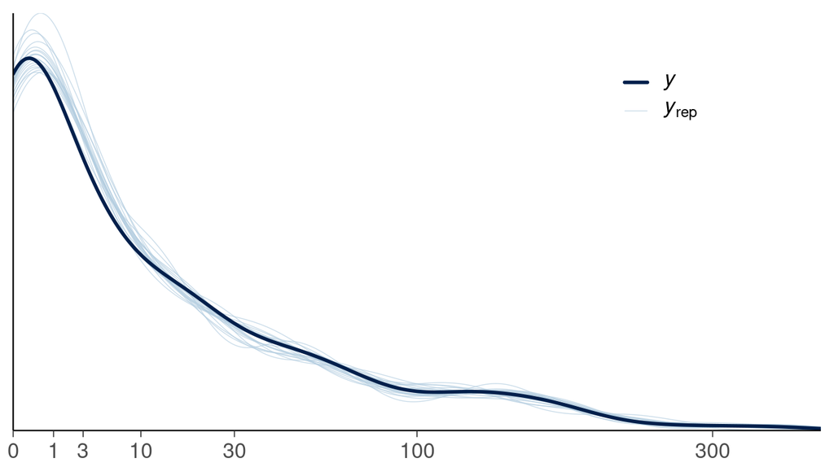

Figure 14

```r
pp_check(fit_pvi, type = "dens_overlay", ndraws = 20) +
  scale_x_sqrt(breaks = c(0, 1, 3, 10, 30, 100, 300),
               lim = c(0, 400)) +
  theme(legend.position = "inside",
        legend.position.inside = c(0.8, 0.8))
```

The match looks perfect, but that can be explained with having one parameter for each observation and kernel density estimate hiding something.

Looking at the discrete rootogram looks also fine.

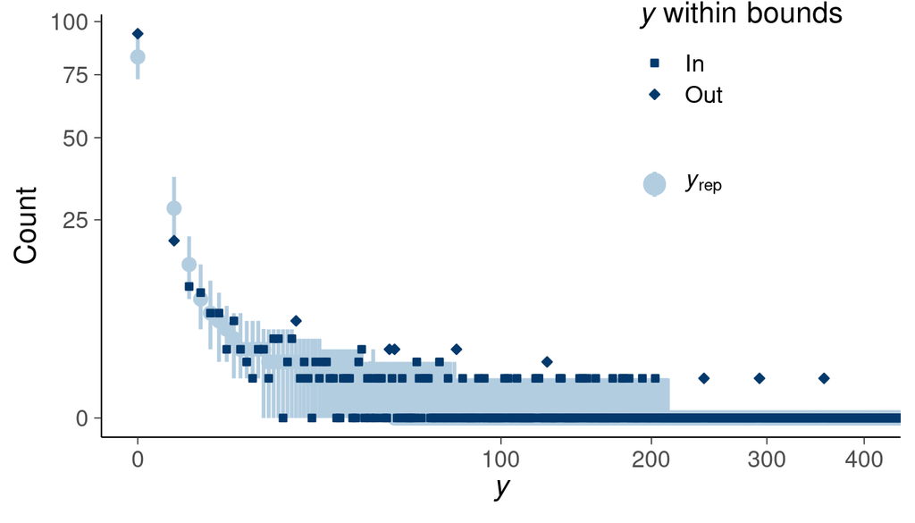

Figure 15

```r
pp_check(fit_pvi, type = "rootogram", style = "discrete") +
  scale_x_sqrt() +
  coord_cartesian(xlim = c(0, 400)) +
  theme(legend.position = "inside",
        legend.position.inside = c(0.8, 0.8))
```

PIT-ECDF plot seems to indicate problems

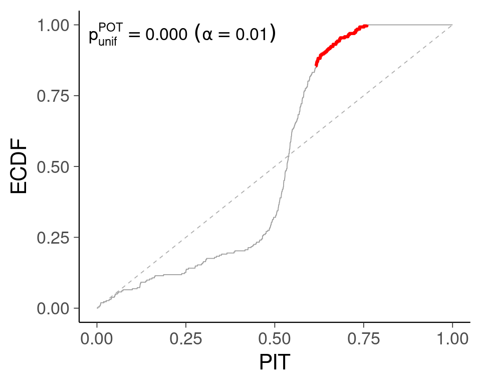

Figure 16

```r
pp_check(fit_pvi, type = "pit_ecdf", method = "correlated")
```

There are too many PIT values near 0.5. If we look at the predictive intervals and observations, we see that many the observations are in the middle of the posterior predictive interval, which can be explained by having very flexible model with one parameter for each observation. Posterior predictive checking is likely to fail with flexible models (having big `p_loo`).

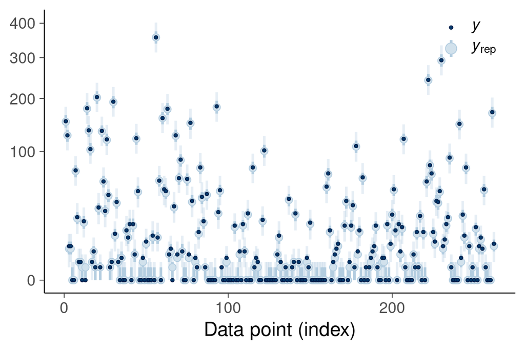

Figure 17

```r
pp_check(fit_pvi, "intervals") +
  scale_y_sqrt() +
  theme(legend.position = "inside",
        legend.position.inside = c(0.9, 0.9))
```

LOO-PIT’s can take into account the model flexibility, if the computation works. In this case LOO-PIT’s look slightly better, but still showing problems, but this is because PSIS-LOO fails (as discussed above)

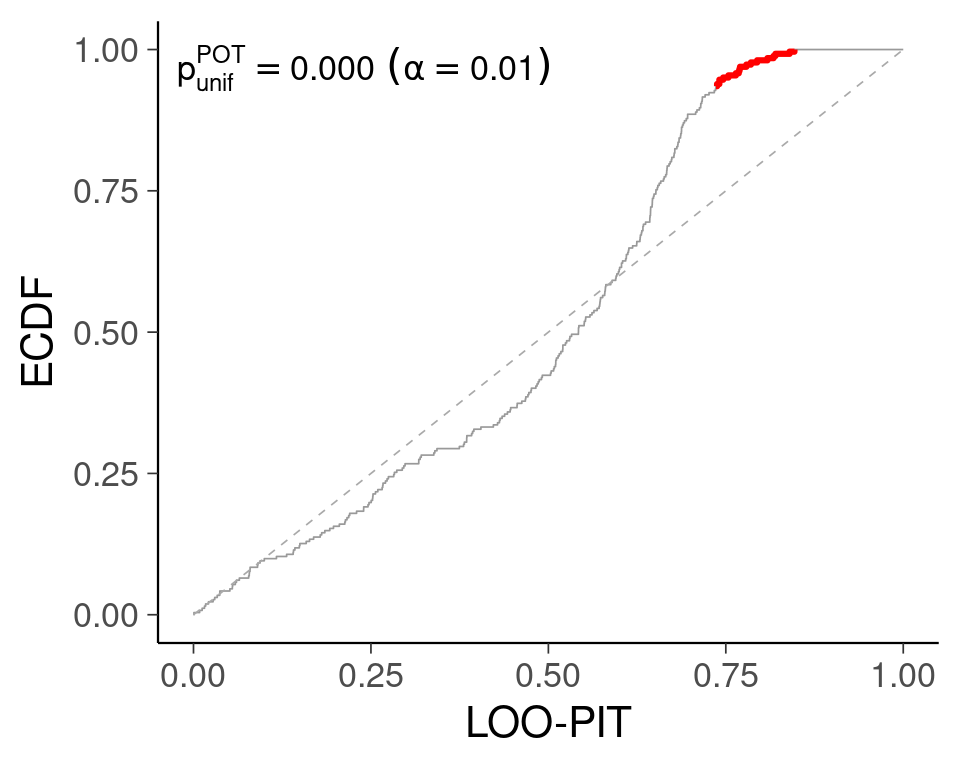

Figure 18

```r
pp_check(fit_pvi, type = "loo_pit_ecdf", method = "correlated")
```

# 6 Poisson model with varying intercept and integrated LOO

Removing one observation changes the posterior for that intercept so much that importance sampling fails (even with Pareto smoothing). We can get improved stability by integrating that intercept out with something more accurate than the importance sampling (Vehtari et al. 2016). If there is only one group or individual specific parameter then we can integrate that out easily with 1D adaptive quadrature. 2 parameters can be handled with nested 1D quadratures, but for more parameters nested quadrature is likely to be too slow and other integration methods are needed.

As we can easily integrate out only 1 (or 2) parameters (per group / individual), it’s not easy to make a generic approach for `rstanarm` and `brms`, and thus we illustrate the approach with direct Stan model code and `cmdstanr`.

The following Stan model uses individual specific intercept term `z[i]` (with common prior with scale `sigmaz`). In the generated quantities, the usual `log_lik` computation is replaced with integrated approach. We also generate `y_loorep` which is the LOO predictive distribution given other parameters than `z`. This is needed to get the correct LOO predictive distributions when combined with integrated PSIS-LOO.

```r
poisson_vi_int <- root("roaches","poisson_vi_integrate.stan")
```

```r
print_stan_file(poisson_vi_int)
```

```stan
// Poisson regression with hierarchical intercept (varying effect)
functions {
  real integrand(real z, real notused, array[] real theta,
               array[] real X_i, array[] int y_i) {
    real sigmaz = theta[1];
    real mu_i = theta[2];
    real p = exp(normal_lpdf(z | 0, sigmaz) + poisson_log_lpmf(y_i | z + mu_i));
    return (is_inf(p) || is_nan(p)) ? 0 : p;
  }
}
data {
  int<lower=0> N;           // number of data points
  int<lower=0> P;           // number of covariates
  matrix[N,P] X;            // covariates
  array[N] int<lower=0> y;  // target
  vector[N] offsett;        // offset (offset variable name is reserved)
  real integrate_1d_reltol;
}
parameters {
  real alpha;               // intercept
  vector[P] beta;           // slope
  vector[N] z;              // individual intercept (varying effect)
  real<lower=0> sigmaz;     // prior scale for z
}
model {
  // priors
  alpha ~ normal(0, 1);
  beta ~ normal(0, 1);
  z ~ normal(0, sigmaz);
  sigmaz ~ normal(0, 1);
  // observation model
  y ~ poisson_log_glm(X, z+offsett+alpha, beta);
}
generated quantities {
  // log_lik for PSIS-LOO
  vector[N] log_lik;
  vector[N] y_rep;
  vector[N] y_loorep;
  for (i in 1:N) {
    // z as posterior draws, this would be challenging for PSIS-LOO (and WAIC)
    // log_lik[i] = poisson_log_glm_lpmf({y[i]} | X[i,], z[i]+offsett[i]+alpha, beta);
    // posterior predictive replicates conditional on p(z[i] | y[i])
    // in theory these could be used with above (non-integrated) log_lik and PSIS-LOO
    // to get draws from LOO predictive distribution, but the distribution of the
    // ratios from above lok_lik is bad
    real mu_i = offsett[i] + alpha + X[i,]*beta;
    y_rep[i] = poisson_log_rng(z[i] + mu_i);
    // we can integrate each z[i] out with 1D adaptive quadrature to get more
    // stable log_lik and corresponding importance ratios
    log_lik[i] = log(integrate_1d(integrand,
                              negative_infinity(),
                              positive_infinity(),
                              append_array({sigmaz}, {mu_i}),
                  {0}, // not used, but an empty array not allowed
                  {y[i]},
                  integrate_1d_reltol));
    // conditional LOO predictive replicates conditional on p(z[i] | sigmaz, mu_i)
    // these combined with integrated log_lik and PSIS-LOO provide
    // more stable LOO predictive distributions
    y_loorep[i] = poisson_log_rng(normal_rng(0, sigmaz) + mu_i);
  }
}
```

We could also move the integrated likelihood to the model block and not use MCMC to sample the varying intercepts at all. This would make marginal posterior easier for MCMC, but using quadrature integration $N$ times for each leapfrog step in Hamiltonian Monte Carlo sampling will increase the sampling time more than what would be the benefit from the simpler marginal posterior. When we do the integration in the generated quantities, the quadrature is computed only for each saved iteration making the computation faster.

Next we compile the model, prepare the data, and sample. `integrate_1d_reltol` sets the relative tolerance for the adaptive 1D quadrature function `integrate_1d` (if with other model and data you see messages about error estimate of integral exceeding the given relative tolerance times norm of integral, you will get NaNs and need to increase the relative tolerance).

We increase the number of sampling iterations to improve effective sample size needed for better LOO-PIT plot.

```r
mod_p_vi <- cmdstan_model(stan_file = poisson_vi_int)
```

```r
datap <- list(N = dim(roaches)[1],
              P = 3,
              offsett = log(roaches$exposure2),
              X = roaches[, c("sqrt_roach1", "treatment", "senior")],
              y = roaches$y,
              integrate_1d_reltol = 1e-6)
fit_p_vi <- mod_p_vi$sample(
  data = datap,
  refresh = 0,
  chains = 4,
  parallel_chains = 4,
  iter_sampling = 8000,
  thin = 8
)
```

The posterior is similar as above for varying intercept Poisson model, as it should be, as the generated quantities is not affecting the posterior.

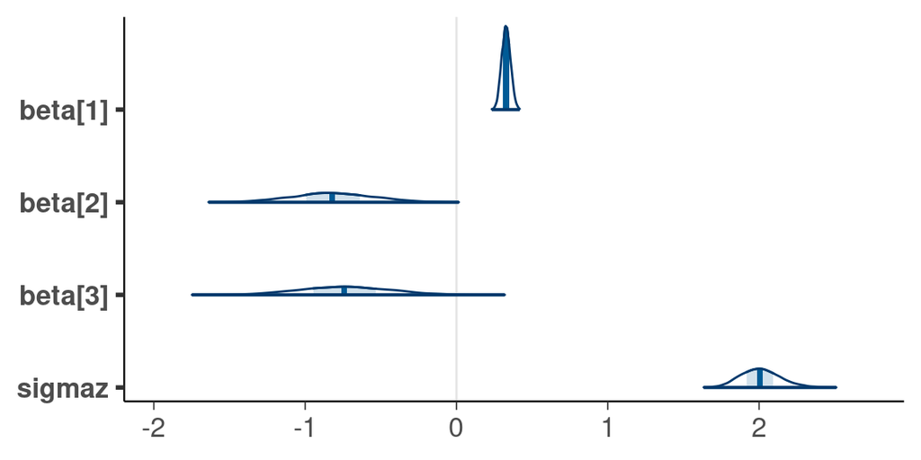

Figure 19

```r
mcmc_areas(as_draws_matrix(fit_p_vi$draws(variables = c("beta", "sigmaz"))),
           prob_outer = .999)
```

Now the PSIS-LOO doesn’t give warnings and the result is close to K-fold-CV.

```r
(loo_p_vi <- fit_p_vi$loo(save_psis = TRUE))
```

```
Computed from 4000 by 262 log-likelihood matrix.

         Estimate   SE
elpd_loo   -878.4 38.2
p_loo         4.8  0.5
looic      1756.8 76.4
------
MCSE of elpd_loo is 0.1.
MCSE and ESS estimates assume MCMC draws (r_eff in [0.3, 0.8]).

All Pareto k estimates are good (k < 0.7).
See help('pareto-k-diagnostic') for details.
```

```r
loo_compare(list(`Poisson var. int. int-LOO` = loo_p_vi, `Neg-bin` = loo_nb))
```

```
                     model elpd_diff se_diff p_worse       diag_diff diag_elpd
 Poisson var. int. int-LOO       0.0     0.0      NA
                   Neg-bin      -3.5     7.6    0.68 |elpd_diff| < 4
```

Comparing to the negative binomial model there is not much difference, and the difference in `elpd_diff` compared to $K$-fold-CV may be partially explained by high variability due to thick tails of the pointwise elpd differences (there may be yhash warning, which in this case can be ignored).

LOO-PIT plot looks good, although a bit more variation, which is probably due to lower effective sample sizes due to more challenging posterior than for negative binomial model.

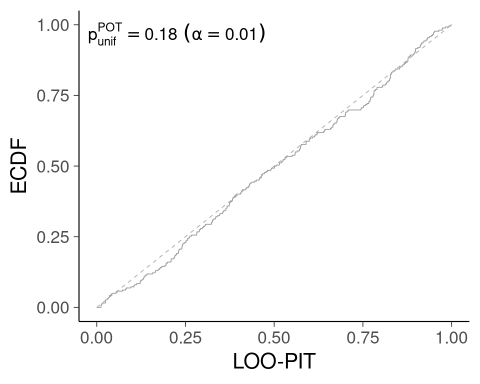

Figure 20

```r
ppc_loo_pit_ecdf(
  y = roaches$y,
  yrep = fit_p_vi$draws(variables = "y_loorep", format = "matrix"),
  psis_object = loo_p_vi$psis_object,
  method = "correlated"
)
```

We check the calibration of predictive probabilities for zeros vs non-zeros. The calibration plot looks better than with negative binomial model. The predicted probabilities have wider range and the calibration curve stays better inside the envelope. Not shown here, but the varying intercepts are quite close to normally distributed (as we expected), and thus the difference to the negative binomial would be mostly the different distribution for the individual variation.

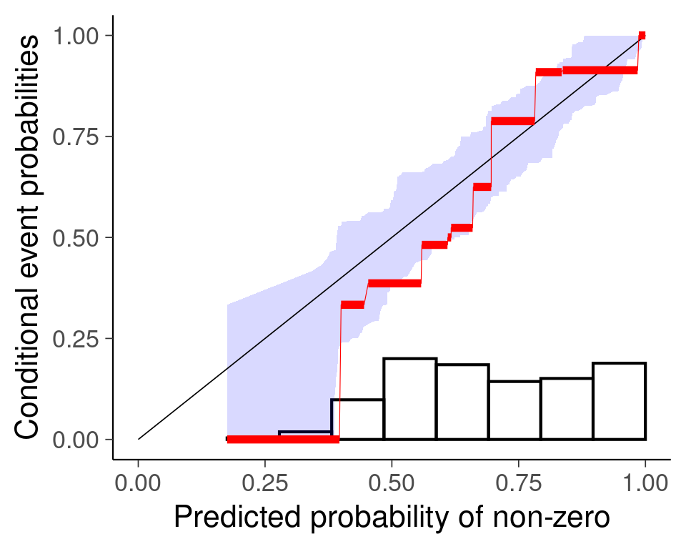

Figure 21

```r
rd <- reliabilitydiag(
  EMOS = E_loo((fit_p_vi$draws(variables = "y_loorep", format = "matrix") > 0) + 0,
               loo_p_vi$psis_object)$value,
  y = as.numeric(roaches$y > 0)
)
autoplot(rd) +
  labs(x = "Predicted probability of non-zero",
       y = "Conditional event probabilities") +
  bayesplot::theme_default(base_family = "sans", base_size = 16)
```

# 7 Zero-inflated negative-binomial model

As the proportion of zeros is quite high in the data and the calibration plot for negative binomial model indicated slight miscalibration in prediction of zeros and non-zeros, it is worthwhile to test also a zero-inflated negative-binomial model, which is a mixture of two models - logistic regression to model the proportion of extra zero counts - negative-binomial model

Fir zero-inflated negative-binomial model.

```r
fit_zinb <-
  brm(bf(y ~ sqrt_roach1 + treatment + senior + offset(log(exposure2)),
         zi ~ sqrt_roach1 + treatment + senior + offset(log(exposure2))),
      family = zero_inflated_negbinomial(), data = roaches,
      prior = c(prior(normal(0, 1), class = "b"),
                prior(normal(0, 1), class = "b", dpar = "zi"),
                prior(normal(0, 1), class = "Intercept", dpar = "zi")),
      seed = 1704009, refresh = 1000)
```

Based on PSIS-LOO, zero-inflated negative-binomial is clearly better.

```r
fit_zinb <- add_criterion(fit_zinb, criterion = "loo", save_psis = TRUE)
```

We get warning about one high Pareto-$\hat{k}$’s in PSIS-LOO, which we can fix with moment matching.

```r
fit_zinb <- add_criterion(fit_zinb, criterion = "loo", save_psis = TRUE,
                          moment_match = TRUE, overwrite = TRUE)
```

`p_loo` is close to the total number of parameters in the model (9), which is a good sign.

```r
(loozinb <- loo(fit_zinb))
```

```
Computed from 4000 by 262 log-likelihood matrix.

         Estimate   SE
elpd_loo   -859.1 37.8
p_loo        10.2  2.7
looic      1718.2 75.6
------
MCSE of elpd_loo is 0.1.
MCSE and ESS estimates assume MCMC draws (r_eff in [0.8, 1.5]).

All Pareto k estimates are good (k < 0.7).
See help('pareto-k-diagnostic') for details.
```

Zero-inflated negative binomial (ZINB) model has clearly better predictive performance than the negative binomial (and all diagnostics are good).

```r
loo_compare(fit_nb, fit_zinb,
            model_names = c("Neg-bin",
                          "ZINB"))
```

```
   model elpd_diff se_diff p_worse diag_diff diag_elpd
    ZINB       0.0     0.0      NA
 Neg-bin     -22.8     6.9    1.00
```

Posterior predictive checking looks good, but there is no clear difference when looking at marginal predictive distributions or LOO-PIT.

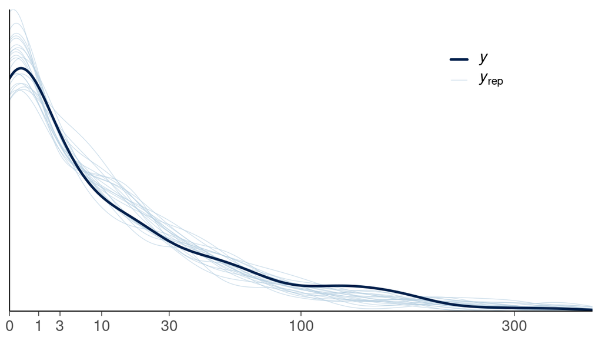

Figure 22

```r
pp_check(fit_zinb, type = "dens_overlay", ndraws = 20) +
  scale_x_sqrt(breaks = c(0, 1, 3, 10, 30, 100, 300),
               lim = c(0, 400)) +
  theme(legend.position = "inside",
        legend.position.inside = c(0.8, 0.8))
```

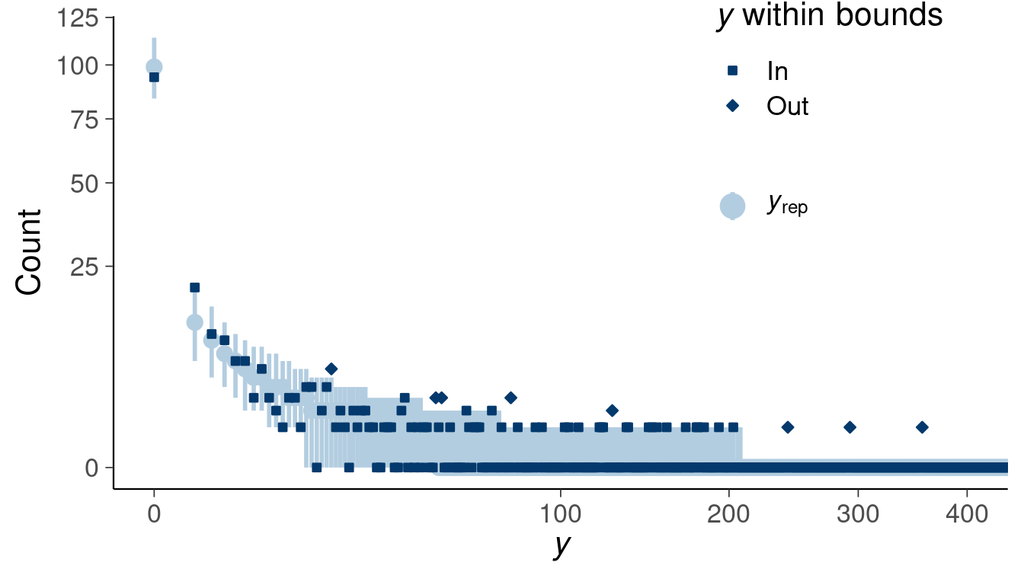

Figure 23

```r
pp_check(fit_zinb, type = "rootogram", style = "discrete") +
  scale_x_sqrt() +
  coord_cartesian(xlim = c(0, 400)) +
  theme(legend.position = "inside",
        legend.position.inside = c(0.8, 0.8))
```

LOO-PIT-ECDF

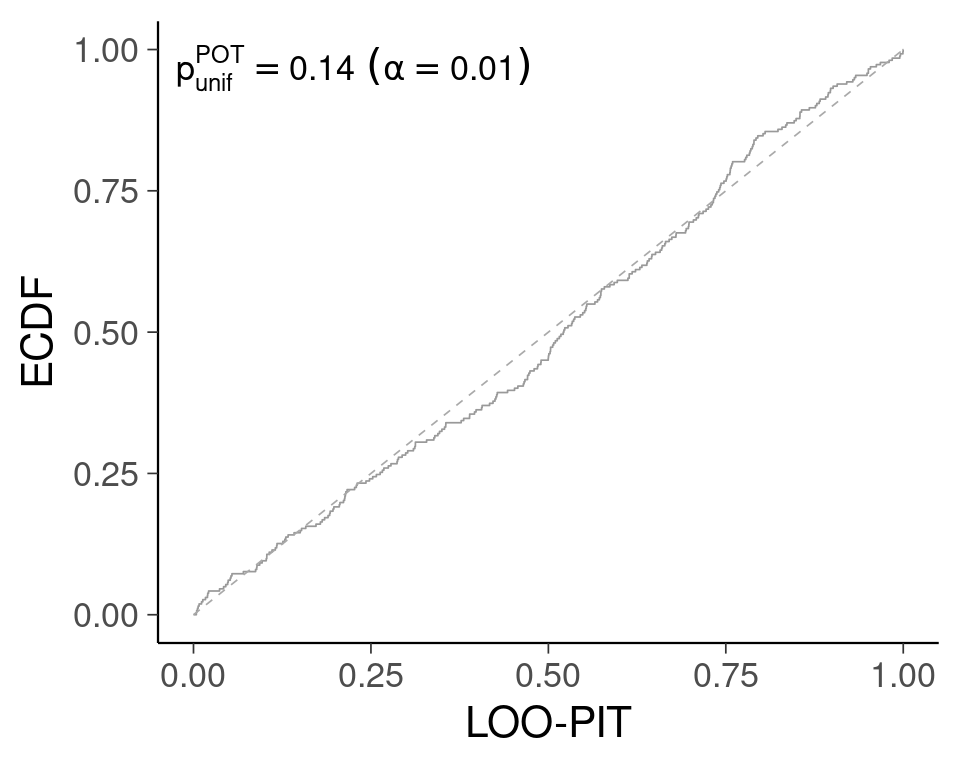

Figure 24

```r
pp_check(fit_zinb, type = "loo_pit_ecdf", moment_match = TRUE,
         method = "correlated")
```

Reliability diagram assessing the calibration of predicted probabilities of zero vs non-zero looks clearly better than the one for negative binomial model.

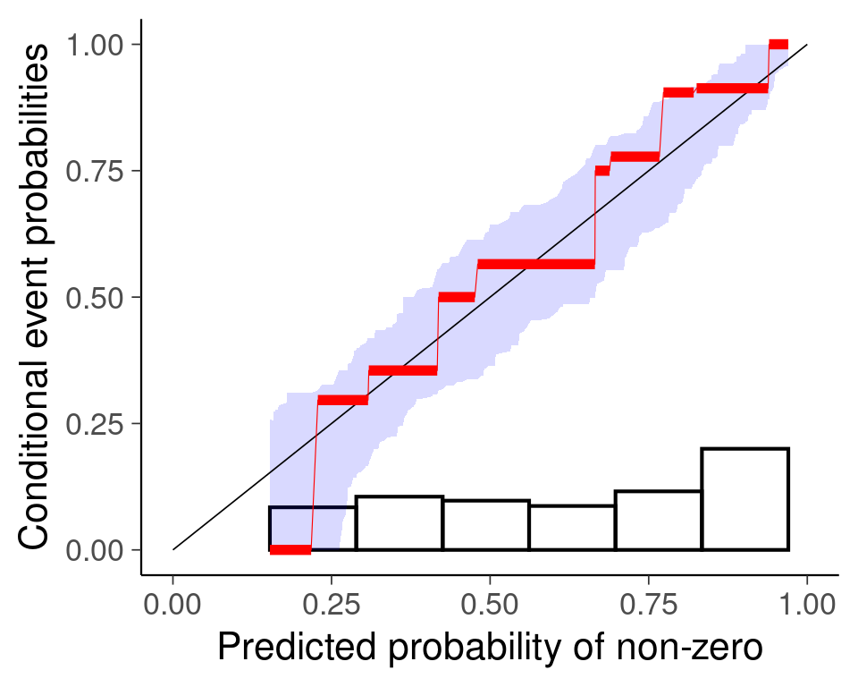

Figure 25

```r
rd <- reliabilitydiag(
  EMOS = E_loo((posterior_predict(fit_zinb) > 0) + 0, loozinb$psis_object)$value,
  y = as.numeric(roaches$y > 0)
)
autoplot(rd) +
  labs(x = "Predicted probability of non-zero",
       y = "Conditional event probabilities") +
  bayesplot::theme_default(base_family = "sans", base_size = 16)
```

Although the models are different, with finite data and wide LOO predictive distributions, there is a limit in which differences can be see in LOO-PIT values. Both negative-binomial and zero-inflated negative binomial are close enough the LOO-PIT can’t see discrepancy from the data, but elpd_loo and calibration plot were able to show that zero-inflation component improves the predictive accuracy and calibration.

## 7.1 Analyse posterior

Plot posterior

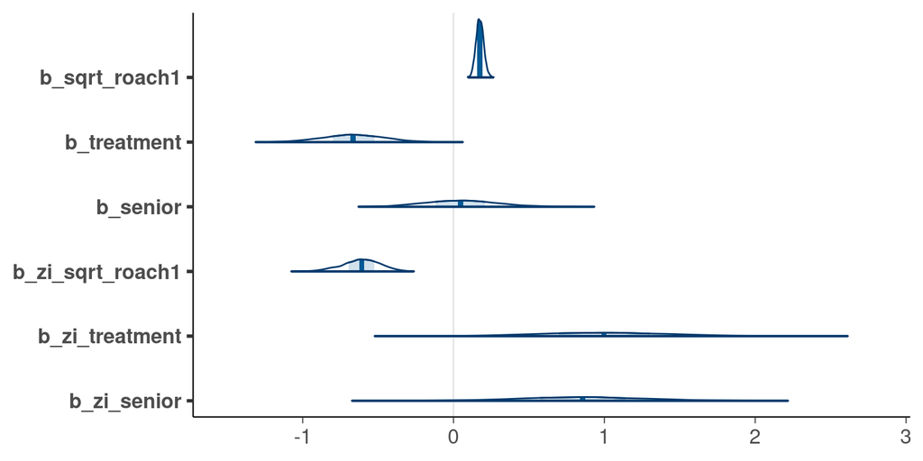

Figure 26

```r
mcmc_areas(as.matrix(fit_zinb)[, 3:8], prob_outer = 0.999)
```

The posterior marginals for negative-binomial part are similar to marginals in the plain negative-binomial model. The marginal effects for the logistic part have opposite sign as the logistic part is modelling the extra zeros.

The treatment effect is now divided between negative-binomial and logistic part. We can use the model to make predictions for the expected number of roaches given treatment and no-treatment to get one marginal posterior to examine.

Expectations of posterior predictive distributions given treatment=0 and treatment=1

```r
pred_zinb <- posterior_epred(fit_zinb,
                           newdata = rbind(mutate(roaches, treatment = 0),
                                           mutate(roaches, treatment = 1)))
```

Ratio of expected number of roaches with vs without treatment

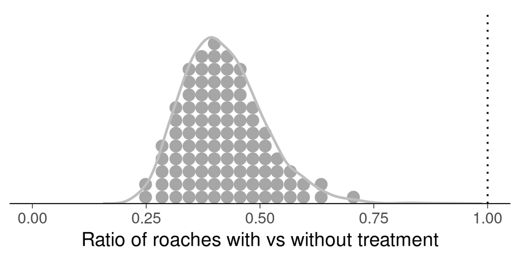

Figure 27

```r
ratio_zinb <- array(rowMeans(pred_zinb[, 263:524] / pred_zinb[, 1:262]),
                    c(1000, 4, 1)) |>
  as_draws_df() |>
  set_variables(variables = "ratio")
ratio_zinb |>
  ggplot(aes(x = ratio)) +
  stat_dots(quantiles = 100) +
  stat_slab(density = "unbounded", trim = FALSE, fill = NA, color = "gray") +
  coord_cartesian(expand = c(bottom = FALSE)) +
  labs(x = "Ratio of roaches with vs without treatment", y = NULL) +
  scale_y_continuous(breaks = NULL) +
  theme(axis.line.y = element_blank(), strip.text.y = element_blank()) +
  xlim(c(0, 1)) +
  ## geom_hline(yintercept = 0, alpha = 0.3) +
  geom_vline(xintercept = 1, linetype = "dotted")
```

The treatment clearly reduces the expected number of roaches.

Assuming our model is causally sensible, we can trust the posterior more if the model has well calibrated predictive distributions (passes posterior and LOO predictive, and calibration checking). For illustration purposes, we compare the posteriors using Poisson, negative binomial and zero-inflated negative binomial.

```r
pred_p <- posterior_epred(fit_p,
                           newdata = rbind(mutate(roaches, treatment = 0),
                                           mutate(roaches, treatment = 1)))
ratio_p <- array(rowMeans(pred_p[, 263:524] / pred_p[, 1:262]),
                 c(1000, 4, 1)) |>
  as_draws_df() |>
  set_variables(variables = "ratio")

pred_nb <- posterior_epred(fit_nb,
                           newdata = rbind(mutate(roaches, treatment = 0),
                                           mutate(roaches, treatment = 1)))
ratio_nb <- array(rowMeans(pred_nb[, 263:524] / pred_nb[, 1:262]),
                  c(1000, 4, 1)) |>
  as_draws_df() |>
  set_variables(variables = "ratio")
```

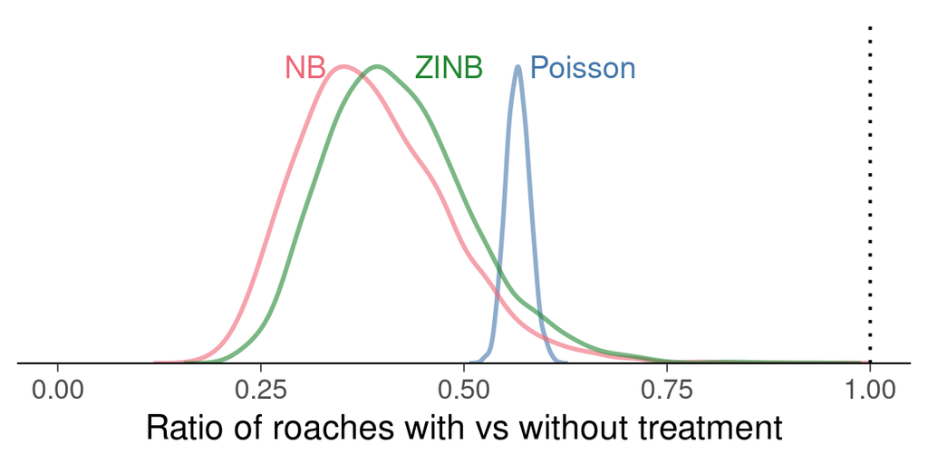

Figure 28

```r
clr <- khroma::colour("bright", names = FALSE)(7)
ratio_zinb |>
  ggplot(aes(x = ratio)) +
  stat_slab(data = ratio_p, density = "unbounded", trim = FALSE,
            fill = NA, color = clr[1], alpha = 0.6) +
  stat_slab(data = ratio_nb, density = "unbounded", trim = FALSE,
            fill = NA, color = clr[2], alpha = 0.6) +
  stat_slab(density = "unbounded", trim = FALSE,
            fill = NA, color = clr[3], alpha = 0.6) +
  labs(x = "Ratio of roaches with vs without treatment", y = NULL) +
  scale_y_continuous(breaks = NULL) +
  coord_cartesian(expand = c(bottom = FALSE)) +
  theme(axis.line.y = element_blank(), strip.text.y = element_blank()) +
  xlim(c(0, 1)) +
  geom_vline(xintercept = 1, linetype = "dotted") +
  annotate(geom = "text", label = "Poisson", x = 0.58, y = 0.9,
           hjust = 0, color = clr[1], size = 5) +
  annotate(geom = "text", label = "NB", x = 0.33, y = 0.9,
           hjust = 1, color = clr[2], size = 5) +
  annotate(geom = "text", label = "ZINB", x = 0.44, y = 0.9,
           hjust = 0, color = clr[3], size = 5)
```

All models show benefit of treatment, but Poisson model is overconfident with too narrow posterior. Posteriors using negative binomial (NB) and zero-inflated negative binomial (ZINB) are quite similar and in this case it would not probably matter for decision making even if the slightly worse negative binomial model would have been used.

## 7.2 Prior sensitivity analysis

Finally we make prior sensitivity analysis by power-scaling both prior and likelihood. As there is posterior dependency between the negative binomial and zero-inflated coefficients, it is not that useful to look at the prior sensitivity for the parameters. We focus on the actual quantity of interest, that is, the ratio of expected number of roaches with vs without treatment.

```r
powerscale_sensitivity(fit_zinb, prediction = \(x, ...) ratio_zinb) |>
                         filter(variable == "ratio") |>
                         mutate(across(where(is.double),  ~num(.x, digits = 2)))
```

```
Sensitivity based on
Prior selection: all priors
Likelihood selection: all data

 variable prior likelihood diagnosis
    ratio  0.04       0.14         -
```

There is no prior sensitivity and the likelihood is informative.

## 7.3 Predictive relevance of covariates

Let’s finally check cross-validation model comparison to see whether improved model has effect on the predictive performance comparison.

```r
fit_zinb_m2 <-
  update(fit_zinb,
         formula = bf(y ~ sqrt_roach1 + senior + offset(log(exposure2)),
                      zi ~ sqrt_roach1 + senior + offset(log(exposure2)))) |>
  add_criterion(criterion = "loo", moment_match = TRUE)
```

```r
loo_compare(fit_zinb, fit_zinb_m2,
            model_names = c("ZINB full model", "ZINB w/o treatment"))
```

```
              model elpd_diff se_diff p_worse diag_diff diag_elpd
    ZINB full model       0.0     0.0      NA
 ZINB w/o treatment      -8.5     4.7    0.97
```

As the variation in the number of roaches is high in both treatment groups, it is difficult to predict the number of roaches per apartment making the difference in predictive performance also small, even we can clearly see clear difference in the expected number of roaches in the groups.

# References

Dimitriadis, T., T. Gneiting, and A. I. Jordan. 2021. “Stable Reliability Diagrams for Probabilistic Classifiers.” *Proceedings of the National Academy of Sciences* 118 (e2016191118).

Gelman, Andrew, and Jennifer Hill. 2007. *Data Analysis Using Regression and Multilevel/Hierarchical Models*. Cambridge University Press.

Paananen, Topi, Juho Piironen, Paul-Christian Bürkner, and Aki Vehtari. 2021. “Implicitly Adaptive Importance Sampling.” *Statistics and Computing* 31 (16).

Säilynoja, T., A. R. Johnson, O. A. Martin, and A. Vehtari. 2025. “Recommendations for Visual Predictive Checks in Bayesian Workflow.” *arXiv Preprint arXiv:2503.01509*.

Vehtari, Aki. 2024. “Default Prior for Negative-Binomial Shape Parameter.”

Vehtari, Aki, Andrew Gelman, and Jonah Gabry. 2017. “Practical Bayesian Model Evaluation Using Leave-One-Out Cross-Validation and WAIC.” *Statistics and Computing* 27 (5): 1413–32. https://doi.org/10.1007/s11222-016-9696-4.

Vehtari, Aki, Tommi Mononen, Ville Tolvanen, Tuomas Sivula, and Ole Winther. 2016. “Bayesian Leave-One-Out Cross-Validation Approximations for Gaussian Latent Variable Models.” *The Journal of Machine Learning Research* 17 (1): 3581–3618.

# Licenses

- Code © 2017–2025, Aki Vehtari, licensed under BSD-3.
- Text © 2017–2025, Aki Vehtari, licensed under CC-BY-NC 4.0.